# Project : Airline on-time performance (exploratory analysis)

- Introduction
- Preliminary Data Wrangling
- Exploratory Data Analysis
- Conclusions

TOC

## Introduction

We are going to investigate flight datasets in order to gain insights on airline on-time performance from 2005 to 2008. The goal is to understand reasons that tend to make a flight delayed or cancelled. In particular, we will be intersted in the following key questions:

- Are there certain destination or arrival cities that are home to more delays or cancellations?
- What are the preferred times for flights to occur?
- Are there any changes over multiple years?
- When is the best time of day/day of week/time of year to fly to minimise delays?
- Do older planes suffer more delays?
- How does the number of people flying between different locations change over time?
- How well does weather predict plane delays?
- Can we detect cascading failures as delays in one airport create delays in others? Are there critical links in the system?
- What are the flight patterns

We will explore the data while having three identities in mind:

- a passenger, who want to know before hand if he may be stuck in an airport waiting for his flight, and plan accordingly.
- an airport administrative, who want to understand issues causing delay, in order to know what he can work on so that he improve the aiport performance.
- a freight company administrative, who also want to understand issues causing delay, in order to know which aspect of his planes he should take note of so that he improve his planes performance.

> **Report date : February 2023**  
> **Written by : [Ekoue LOGOSU-TEKO](https://www.linkedin.com/in/ekouelogosuteko/?locale=en_US)**

```python
# import all packages and set plots to be embedded inline
import numpy as np
import pandas as pd
import matplotlib.pyplot as plt
import seaborn as sb

from dateutil.parser import parse
from datetime import datetime

%matplotlib inline
```

> Load in your dataset and describe its properties through the questions below. Try and motivate your exploration goals through this section.

## Preliminary Data Wrangling

TOC

### General Properties

Our main data come from 04 different datasets, each one targeting a particular year, from 2005 to 2008. We will load each of them.

```python
flight_df_05 = pd.read_csv("./datasets/2005.csv")
flight_df_05.head().T
```

|  | 0 | 1 | 2 | 3 | 4 |
| --- | --- | --- | --- | --- | --- |
| Year | 2005 | 2005 | 2005 | 2005 | 2005 |
| Month | 1 | 1 | 1 | 1 | 1 |
| DayofMonth | 28 | 29 | 30 | 31 | 2 |
| DayOfWeek | 5 | 6 | 7 | 1 | 7 |
| DepTime | 1603.0 | 1559.0 | 1603.0 | 1556.0 | 1934.0 |
| CRSDepTime | 1605 | 1605 | 1610 | 1605 | 1900 |
| ArrTime | 1741.0 | 1736.0 | 1741.0 | 1726.0 | 2235.0 |
| CRSArrTime | 1759 | 1759 | 1805 | 1759 | 2232 |
| UniqueCarrier | UA | UA | UA | UA | UA |
| FlightNum | 541 | 541 | 541 | 541 | 542 |
| TailNum | N935UA | N941UA | N342UA | N326UA | N902UA |
| ActualElapsedTime | 158.0 | 157.0 | 158.0 | 150.0 | 121.0 |
| CRSElapsedTime | 174 | 174 | 175 | 174 | 152 |
| AirTime | 131.0 | 136.0 | 131.0 | 129.0 | 106.0 |
| ArrDelay | -18.0 | -23.0 | -24.0 | -33.0 | 3.0 |
| DepDelay | -2.0 | -6.0 | -7.0 | -9.0 | 34.0 |
| Origin | BOS | BOS | BOS | BOS | ORD |
| Dest | ORD | ORD | ORD | ORD | BOS |
| Distance | 867 | 867 | 867 | 867 | 867 |
| TaxiIn | 4 | 6 | 9 | 11 | 5 |
| TaxiOut | 23 | 15 | 18 | 10 | 10 |
| Cancelled | 0 | 0 | 0 | 0 | 0 |
| CancellationCode | NaN | NaN | NaN | NaN | NaN |
| Diverted | 0 | 0 | 0 | 0 | 0 |
| CarrierDelay | 0 | 0 | 0 | 0 | 0 |
| WeatherDelay | 0 | 0 | 0 | 0 | 0 |
| NASDelay | 0 | 0 | 0 | 0 | 0 |
| SecurityDelay | 0 | 0 | 0 | 0 | 0 |
| LateAircraftDelay | 0 | 0 | 0 | 0 | 0 |

```python
flight_df_06 = pd.read_csv("./datasets/2006.csv")
flight_df_06.head().T
```

|  | 0 | 1 | 2 | 3 | 4 |
| --- | --- | --- | --- | --- | --- |
| Year | 2006 | 2006 | 2006 | 2006 | 2006 |
| Month | 1 | 1 | 1 | 1 | 1 |
| DayofMonth | 11 | 11 | 11 | 11 | 11 |
| DayOfWeek | 3 | 3 | 3 | 3 | 3 |
| DepTime | 743.0 | 1053.0 | 1915.0 | 1753.0 | 824.0 |
| CRSDepTime | 745 | 1053 | 1915 | 1755 | 832 |
| ArrTime | 1024.0 | 1313.0 | 2110.0 | 1925.0 | 1015.0 |
| CRSArrTime | 1018 | 1318 | 2133 | 1933 | 1015 |
| UniqueCarrier | US | US | US | US | US |
| FlightNum | 343 | 613 | 617 | 300 | 765 |
| TailNum | N657AW | N834AW | N605AW | N312AW | N309AW |
| ActualElapsedTime | 281.0 | 260.0 | 235.0 | 152.0 | 171.0 |
| CRSElapsedTime | 273.0 | 265.0 | 258.0 | 158.0 | 163.0 |
| AirTime | 223.0 | 214.0 | 220.0 | 126.0 | 132.0 |
| ArrDelay | 6.0 | -5.0 | -23.0 | -8.0 | 0.0 |
| DepDelay | -2.0 | 0.0 | 0.0 | -2.0 | -8.0 |
| Origin | ATL | ATL | ATL | AUS | AUS |
| Dest | PHX | PHX | PHX | PHX | PHX |
| Distance | 1587 | 1587 | 1587 | 872 | 872 |
| TaxiIn | 45 | 27 | 4 | 16 | 27 |
| TaxiOut | 13 | 19 | 11 | 10 | 12 |
| Cancelled | 0 | 0 | 0 | 0 | 0 |
| CancellationCode | NaN | NaN | NaN | NaN | NaN |
| Diverted | 0 | 0 | 0 | 0 | 0 |
| CarrierDelay | 0 | 0 | 0 | 0 | 0 |
| WeatherDelay | 0 | 0 | 0 | 0 | 0 |
| NASDelay | 0 | 0 | 0 | 0 | 0 |
| SecurityDelay | 0 | 0 | 0 | 0 | 0 |
| LateAircraftDelay | 0 | 0 | 0 | 0 | 0 |

```python
flight_df_07 = pd.read_csv("./datasets/2007.csv")
flight_df_07.head().T
```

|  | 0 | 1 | 2 | 3 | 4 |
| --- | --- | --- | --- | --- | --- |
| Year | 2007 | 2007 | 2007 | 2007 | 2007 |
| Month | 1 | 1 | 1 | 1 | 1 |
| DayofMonth | 1 | 1 | 1 | 1 | 1 |
| DayOfWeek | 1 | 1 | 1 | 1 | 1 |
| DepTime | 1232.0 | 1918.0 | 2206.0 | 1230.0 | 831.0 |
| CRSDepTime | 1225 | 1905 | 2130 | 1200 | 830 |
| ArrTime | 1341.0 | 2043.0 | 2334.0 | 1356.0 | 957.0 |
| CRSArrTime | 1340 | 2035 | 2300 | 1330 | 1000 |
| UniqueCarrier | WN | WN | WN | WN | WN |
| FlightNum | 2891 | 462 | 1229 | 1355 | 2278 |
| TailNum | N351 | N370 | N685 | N364 | N480 |
| ActualElapsedTime | 69.0 | 85.0 | 88.0 | 86.0 | 86.0 |
| CRSElapsedTime | 75.0 | 90.0 | 90.0 | 90.0 | 90.0 |
| AirTime | 54.0 | 74.0 | 73.0 | 75.0 | 74.0 |
| ArrDelay | 1.0 | 8.0 | 34.0 | 26.0 | -3.0 |
| DepDelay | 7.0 | 13.0 | 36.0 | 30.0 | 1.0 |
| Origin | SMF | SMF | SMF | SMF | SMF |
| Dest | ONT | PDX | PDX | PDX | PDX |
| Distance | 389 | 479 | 479 | 479 | 479 |
| TaxiIn | 4 | 5 | 6 | 3 | 3 |
| TaxiOut | 11 | 6 | 9 | 8 | 9 |
| Cancelled | 0 | 0 | 0 | 0 | 0 |
| CancellationCode | NaN | NaN | NaN | NaN | NaN |
| Diverted | 0 | 0 | 0 | 0 | 0 |
| CarrierDelay | 0 | 0 | 3 | 23 | 0 |
| WeatherDelay | 0 | 0 | 0 | 0 | 0 |
| NASDelay | 0 | 0 | 0 | 0 | 0 |
| SecurityDelay | 0 | 0 | 0 | 0 | 0 |
| LateAircraftDelay | 0 | 0 | 31 | 3 | 0 |

```python
flight_df_08 = pd.read_csv("./datasets/2008.csv")
flight_df_08.head().T
```

|  | 0 | 1 | 2 | 3 | 4 |
| --- | --- | --- | --- | --- | --- |
| Year | 2008 | 2008 | 2008 | 2008 | 2008 |
| Month | 1 | 1 | 1 | 1 | 1 |
| DayofMonth | 3 | 3 | 3 | 3 | 3 |
| DayOfWeek | 4 | 4 | 4 | 4 | 4 |
| DepTime | 1343.0 | 1125.0 | 2009.0 | 903.0 | 1423.0 |
| CRSDepTime | 1325 | 1120 | 2015 | 855 | 1400 |
| ArrTime | 1451.0 | 1247.0 | 2136.0 | 1203.0 | 1726.0 |
| CRSArrTime | 1435 | 1245 | 2140 | 1205 | 1710 |
| UniqueCarrier | WN | WN | WN | WN | WN |
| FlightNum | 588 | 1343 | 3841 | 3 | 25 |
| TailNum | N240WN | N523SW | N280WN | N308SA | N462WN |
| ActualElapsedTime | 68.0 | 82.0 | 87.0 | 120.0 | 123.0 |
| CRSElapsedTime | 70.0 | 85.0 | 85.0 | 130.0 | 130.0 |
| AirTime | 55.0 | 71.0 | 71.0 | 108.0 | 107.0 |
| ArrDelay | 16.0 | 2.0 | -4.0 | -2.0 | 16.0 |
| DepDelay | 18.0 | 5.0 | -6.0 | 8.0 | 23.0 |
| Origin | HOU | HOU | HOU | HOU | HOU |
| Dest | LIT | MAF | MAF | MCO | MCO |
| Distance | 393 | 441 | 441 | 848 | 848 |
| TaxiIn | 4.0 | 3.0 | 2.0 | 5.0 | 6.0 |
| TaxiOut | 9.0 | 8.0 | 14.0 | 7.0 | 10.0 |
| Cancelled | 0 | 0 | 0 | 0 | 0 |
| CancellationCode | NaN | NaN | NaN | NaN | NaN |
| Diverted | 0 | 0 | 0 | 0 | 0 |
| CarrierDelay | 16.0 | NaN | NaN | NaN | 16.0 |
| WeatherDelay | 0.0 | NaN | NaN | NaN | 0.0 |
| NASDelay | 0.0 | NaN | NaN | NaN | 0.0 |
| SecurityDelay | 0.0 | NaN | NaN | NaN | 0.0 |
| LateAircraftDelay | 0.0 | NaN | NaN | NaN | 0.0 |

```python
flight_df_05.shape
```

```
(7140596, 29)
```

### Structure of the dataset

We have 29 features, whose signification we obtained through a search over [the net](https://www.transtats.bts.gov/DatabaseInfo.asp?QO_VQ=EFD&Yv0x=D) :

- **Year**: year (e.g. 2008)
- **Month**: 1-12
- **DayofMonth**: 1-31
- **DayOfWeek**: 1 (Monday) - 7 (Sunday)
- **DepTime**: Actual departure time (local, hhmm).
- **CRSDepTime**: Scheduled departure time (local, hhmm).
- **ArrTime**: Actual arrival time (local, hhmm).
- **CRSArrTime**: Scheduled arrival time (local, hhmm).
- **UniqueCarrier**: Unique Carrier Code. It is the Carrier Code most recently used by a carrier. A numeric suffix is used to distinguish duplicate codes, for example, PA, PA (1), PA (2). This field is to be used to perform analysis of data reported by one and only one carrier.
- **FlightNum**: A one to four character alpha-numeric code for a particular flight.
- **TailNum**: Plane tail number; aircraft registration, unique aircraft identifier.
- **CRSElapsedTime**: Scheduled elapsed time computed from gate departure time to gate arrival time. In minutes.
- **ActualElapsedTime**: elapsed time computed from gate departure time to gate arrival time. In minutes.
- **AirTime**: The time spent by the plane in the air. In minutes.
- **ArrDelay**: Arrival delay of the flight, in minutes. Arrival delay equals the difference of the actual arrival time minus the scheduled arrival time. A flight is considered on-time when it arrives less than 15 minutes after its published arrival time.
- **DepDelay**: Departure delay of the flight, in minutes. It is the difference between the scheduled departure time and the actual departure time from the origin airport gate.
- **Origin**: Origin IATA airport code. Supposedly, this is the origin airport.
- **Dest**: Destination IATA airport code. Supposedly, this is the destination airport.
- **Distance**: The distance of the flight. In miles.
- **TaxiIn**: Taxi-in time, in minutes. The time elapsed between wheels down and arrival at the destination airport gate.
- **TaxiOut**: Taxi-out time, in minutes. The time elapsed between departure from the origin airport gate and wheels off.
- **Cancelled**: A flight that was listed in a carrier's computer reservation system during the seven calendar days prior to scheduled departure but was not operated.
- **CancellationCode**: reason for cancellation (A = carrier, B = weather, C = NAS, D = security)
- **Diverted**: 1 = yes, 0 = no. Indicate whether or not a flight was required to land at a destination other than the original scheduled destination for reasons beyond the control of the pilot/company.
- **CarrierDelay**: In minutes. Carrier delay record the delays that are within the control of the air carrier. Examples of occurrences that may determine carrier delay are: aircraft cleaning, aircraft damage, awaiting the arrival of connecting passengers or crew, baggage, bird strike, cargo loading, catering, computer, outage-carrier equipment, crew legality (pilot or attendant rest), damage by hazardous goods, engineering inspection, fueling, handling disabled passengers, late crew, lavatory servicing, maintenance, oversales, potable water servicing, removal of unruly passenger, slow boarding or seating, stowing carry-on baggage, weight and balance delays.
- **WeatherDelay**: In minutes. Weather delay is caused by extreme or hazardous weather conditions that are forecasted or manifest themselves on point of departure, enroute, or on point of arrival.
- **NASDelay**: In minutes. Delay that is within the control of the National Airspace System (NAS) may include: non-extreme weather conditions, airport operations, heavy traffic volume, air traffic control, etc.
- **SecurityDelay**: In minutes. Security delay is caused by evacuation of a terminal or concourse, re-boarding of aircraft because of security breach, inoperative screening equipment and/or long lines in excess of 29 minutes at screening areas.
- **LateAircraftDelay** in minutes: Arrival delay at an airport due to the late arrival of the same aircraft at a previous airport. The ripple effect of an earlier delay at downstream airports is referred to as delay propagation.

*Note* : CRS stand for Computer Reservation System. CRS provide information on airline schedules, fares and seat availability to travel agencies and allow agents to book seats and issue tickets.

A quick observation : we have our main data separated over 04 datasets, we will later fuse them together as a whole in one dataframe.

We also have complementary datasets, which give more informations about variables in the main datasets.

```python
# Load freight companies data
carrier_df = pd.read_csv("./datasets/carriers.csv")
carrier_df.head()
```

|  | Code | Description |
| --- | --- | --- |
| 0 | 02Q | Titan Airways |
| 1 | 04Q | Tradewind Aviation |
| 2 | 05Q | Comlux Aviation, AG |
| 3 | 06Q | Master Top Linhas Aereas Ltd. |
| 4 | 07Q | Flair Airlines Ltd. |

```python
# Load planes data
plane_df = pd.read_csv("./datasets/plane-data.csv")
plane_df
```

|  | tailnum | type | manufacturer | issue_date | model | status | aircraft_type | engine_type | year |
| --- | --- | --- | --- | --- | --- | --- | --- | --- | --- |
| 0 | N050AA | NaN | NaN | NaN | NaN | NaN | NaN | NaN | NaN |
| 1 | N051AA | NaN | NaN | NaN | NaN | NaN | NaN | NaN | NaN |
| 2 | N052AA | NaN | NaN | NaN | NaN | NaN | NaN | NaN | NaN |
| 3 | N054AA | NaN | NaN | NaN | NaN | NaN | NaN | NaN | NaN |
| 4 | N055AA | NaN | NaN | NaN | NaN | NaN | NaN | NaN | NaN |
| ... | ... | ... | ... | ... | ... | ... | ... | ... | ... |
| 5024 | N997DL | Corporation | MCDONNELL DOUGLAS AIRCRAFT CO | 03/11/1992 | MD-88 | Valid | Fixed Wing Multi-Engine | Turbo-Fan | 1992 |
| 5025 | N998AT | Corporation | BOEING | 01/23/2003 | 717-200 | Valid | Fixed Wing Multi-Engine | Turbo-Fan | 2002 |
| 5026 | N998DL | Corporation | MCDONNELL DOUGLAS CORPORATION | 04/02/1992 | MD-88 | Valid | Fixed Wing Multi-Engine | Turbo-Jet | 1992 |
| 5027 | N999CA | Foreign Corporation | CANADAIR | 07/09/2008 | CL-600-2B19 | Valid | Fixed Wing Multi-Engine | Turbo-Jet | 1998 |
| 5028 | N999DN | Corporation | MCDONNELL DOUGLAS CORPORATION | 04/02/1992 | MD-88 | Valid | Fixed Wing Multi-Engine | Turbo-Jet | 1992 |

5029 rows × 9 columns

```python
plane_df["manufacturer"].unique()
```

```
array([nan, 'EMBRAER', 'AIRBUS INDUSTRIE', 'BOEING', 'DOUGLAS',
       'MCDONNELL DOUGLAS', 'CANADAIR', 'BOMBARDIER INC', 'AIRBUS',
       'CESSNA', 'SAAB-SCANIA', 'BEECH', 'SIKORSKY',
       'GULFSTREAM AEROSPACE', 'AEROSPATIALE', 'PIPER', 'AGUSTA SPA',
       'AERO COMMANDER', 'PAIR MIKE E', 'AVIAT AIRCRAFT INC', 'RAVEN',
       'DEHAVILLAND', 'WOBIG WAYNE R', 'BELL', 'FREDERICK CHRIS K',
       'FRIEDEMANN JON', 'STINNETT RON', 'HELIO', 'LEBLANC GLENN T',
       'MARZ BARRY', 'MORSE GEORGE JR', 'AEROSPATIALE/ALENIA',
       'BAUMAN RANDY', 'DIAMOND AIRCRAFT IND INC', 'BOEING OF CANADA LTD',
       'MCDONNELL DOUGLAS CORPORATION', 'MCDONNELL DOUGLAS AIRCRAFT CO',
       'COBB INTL/DBA ROTORWAY INTL IN', 'AERONCA', 'MAULE'], dtype=object)
```

```python
# Load airports data
airport_df = pd.read_csv("./datasets/airports.csv")
airport_df.head()
```

|  | iata | airport | city | state | country | lat | long |
| --- | --- | --- | --- | --- | --- | --- | --- |
| 0 | 00M | Thigpen | Bay Springs | MS | USA | 31.953765 | -89.234505 |
| 1 | 00R | Livingston Municipal | Livingston | TX | USA | 30.685861 | -95.017928 |
| 2 | 00V | Meadow Lake | Colorado Springs | CO | USA | 38.945749 | -104.569893 |
| 3 | 01G | Perry-Warsaw | Perry | NY | USA | 42.741347 | -78.052081 |
| 4 | 01J | Hilliard Airpark | Hilliard | FL | USA | 30.688012 | -81.905944 |

Our analysis will be focused on the features of our main datasets, while the secondary datasets are will provide additional informations when necessary (for example, provide the full name of an aiport instead of its IATA code in an plot).

In the main dataset, we will mainly be interested in the time-related features, while distance, delay reasons, and location related features will be used to support our main investigation.

Let's immediatly fuse the content of our main datasets.

```python
# Observing the shape of the datasets from each year
flight_df_05.shape, flight_df_06.shape, flight_df_07.shape, flight_df_08.shape
```

```
((7140596, 29), (7141922, 29), (7453215, 29), (2389217, 29))
```

We will take note of the fact that the data of 2008 is little compared to the others years.

```python
# Fusing the datasets from each year so that our data become a whole
flight_df = pd.concat([flight_df_05,flight_df_06,flight_df_07,flight_df_08],ignore_index=True)
flight_df.shape
```

```
(24124950, 29)
```

```python
flight_df.info()
```

```
<class 'pandas.core.frame.DataFrame'>
RangeIndex: 24124950 entries, 0 to 24124949
Data columns (total 29 columns):
 #   Column             Dtype
---  ------             -----
 0   Year               int64
 1   Month              int64
 2   DayofMonth         int64
 3   DayOfWeek          int64
 4   DepTime            float64
 5   CRSDepTime         int64
 6   ArrTime            float64
 7   CRSArrTime         int64
 8   UniqueCarrier      object
 9   FlightNum          int64
```

[output cut: 21 more lines]

```python
# Check N/A values count for each variable
flight_df.isna().sum()
```

```
Year                        0
Month                       0
DayofMonth                  0
DayOfWeek                   0
DepTime                480854
CRSDepTime                  0
ArrTime                533901
CRSArrTime                  0
UniqueCarrier               0
FlightNum                   0
TailNum                 42474
ActualElapsedTime      533901
CRSElapsedTime           1405
AirTime                533901
ArrDelay               533901
DepDelay               480854
Origin                      0
Dest                        0
Distance                    0
TaxiIn                  70096
TaxiOut                 64442
Cancelled                   0
CancellationCode     23644094
Diverted                    0
CarrierDelay          1804634
WeatherDelay          1804634
NASDelay              1804634
SecurityDelay         1804634
LateAircraftDelay     1804634
dtype: int64
```

```python
# Check null values count for each variable
flight_df.isnull().sum()
```

```
Year                        0
Month                       0
DayofMonth                  0
DayOfWeek                   0
DepTime                480854
CRSDepTime                  0
ArrTime                533901
CRSArrTime                  0
UniqueCarrier               0
FlightNum                   0
TailNum                 42474
ActualElapsedTime      533901
CRSElapsedTime           1405
AirTime                533901
ArrDelay               533901
DepDelay               480854
Origin                      0
Dest                        0
Distance                    0
TaxiIn                  70096
TaxiOut                 64442
Cancelled                   0
CancellationCode     23644094
Diverted                    0
CarrierDelay          1804634
WeatherDelay          1804634
NASDelay              1804634
SecurityDelay         1804634
LateAircraftDelay     1804634
dtype: int64
```

N/A check and null check are giving the same result, so there is nothing to worry about there underlying content

```python
flight_df.head().T
```

|  | 0 | 1 | 2 | 3 | 4 |
| --- | --- | --- | --- | --- | --- |
| Year | 2005 | 2005 | 2005 | 2005 | 2005 |
| Month | 1 | 1 | 1 | 1 | 1 |
| DayofMonth | 28 | 29 | 30 | 31 | 2 |
| DayOfWeek | 5 | 6 | 7 | 1 | 7 |
| DepTime | 1603.0 | 1559.0 | 1603.0 | 1556.0 | 1934.0 |
| CRSDepTime | 1605 | 1605 | 1610 | 1605 | 1900 |
| ArrTime | 1741.0 | 1736.0 | 1741.0 | 1726.0 | 2235.0 |
| CRSArrTime | 1759 | 1759 | 1805 | 1759 | 2232 |
| UniqueCarrier | UA | UA | UA | UA | UA |
| FlightNum | 541 | 541 | 541 | 541 | 542 |
| TailNum | N935UA | N941UA | N342UA | N326UA | N902UA |
| ActualElapsedTime | 158.0 | 157.0 | 158.0 | 150.0 | 121.0 |
| CRSElapsedTime | 174.0 | 174.0 | 175.0 | 174.0 | 152.0 |
| AirTime | 131.0 | 136.0 | 131.0 | 129.0 | 106.0 |
| ArrDelay | -18.0 | -23.0 | -24.0 | -33.0 | 3.0 |
| DepDelay | -2.0 | -6.0 | -7.0 | -9.0 | 34.0 |
| Origin | BOS | BOS | BOS | BOS | ORD |
| Dest | ORD | ORD | ORD | ORD | BOS |
| Distance | 867 | 867 | 867 | 867 | 867 |
| TaxiIn | 4.0 | 6.0 | 9.0 | 11.0 | 5.0 |
| TaxiOut | 23.0 | 15.0 | 18.0 | 10.0 | 10.0 |
| Cancelled | 0 | 0 | 0 | 0 | 0 |
| CancellationCode | NaN | NaN | NaN | NaN | NaN |
| Diverted | 0 | 0 | 0 | 0 | 0 |
| CarrierDelay | 0.0 | 0.0 | 0.0 | 0.0 | 0.0 |
| WeatherDelay | 0.0 | 0.0 | 0.0 | 0.0 | 0.0 |
| NASDelay | 0.0 | 0.0 | 0.0 | 0.0 | 0.0 |
| SecurityDelay | 0.0 | 0.0 | 0.0 | 0.0 | 0.0 |
| LateAircraftDelay | 0.0 | 0.0 | 0.0 | 0.0 | 0.0 |

```python
flight_df.shape
```

```
(24124950, 29)
```

```python
# flight_df.dropna(inplace=True)
# flight_df.shape
```

One thing to note is that there are some time data under one or two digit, instead of four digits. For example, `55` or `7`. Such an entry should originally be prefixed by `0`s under their string form, before having the `0`s removed when they were parsed to int. For example `0055` or `0007` which will stand for `00:05` and `00:07`.  
And example of such an entry is in the next cell. We will take note of that case so that we take the appropriate steps when working on the time related variables.

```python
flight_df.iloc[166,:]
```

```
Year                   2005
Month                     1
DayofMonth                5
DayOfWeek                 3
DepTime                55.0
CRSDepTime             2115
ArrTime               309.0
CRSArrTime             2319
UniqueCarrier            UA
FlightNum               546
TailNum              N819UA
ActualElapsedTime      74.0
CRSElapsedTime         64.0
AirTime                42.0
ArrDelay              230.0
DepDelay              220.0
Origin                  ORD
Dest                    DAY
Distance                240
TaxiIn                  4.0
TaxiOut                28.0
Cancelled                 0
CancellationCode        NaN
Diverted                  0
CarrierDelay            0.0
WeatherDelay           44.0
NASDelay               10.0
SecurityDelay           0.0
LateAircraftDelay     176.0
Name: 166, dtype: object
```

There is another thing to take not of : `DepDelay` computed the difference in minute between `DepTime` and `CRSDepTime`; but sometimes, there are discordance between `DepDelay` and the sum of `CarrierDelay, WeatherDelay, NASDelay, SecurityDelay, LateAircraftDelay`.

This may be related to the fact that not all delay reasons are recorded in our dataset. An example of such case is illustrated in the next cell.

```python
# Example of flights were there are discordance between DepDelay and the sum of delay reasons
flight_df.loc[[4,5,6,7,10],["DepTime","CRSDepTime","DepDelay","CarrierDelay","WeatherDelay",
                            "NASDelay","SecurityDelay","LateAircraftDelay"]].T
```

|  | 4 | 5 | 6 | 7 | 10 |
| --- | --- | --- | --- | --- | --- |
| DepTime | 1934.0 | 2042.0 | 2046.0 | 2110.0 | 1917.0 |
| CRSDepTime | 1900.0 | 1900.0 | 1900.0 | 1900.0 | 1900.0 |
| DepDelay | 34.0 | 102.0 | 106.0 | 130.0 | 17.0 |
| CarrierDelay | 0.0 | 23.0 | 46.0 | 16.0 | 17.0 |
| WeatherDelay | 0.0 | 0.0 | 0.0 | 0.0 | 0.0 |
| NASDelay | 0.0 | 0.0 | 0.0 | 0.0 | 0.0 |
| SecurityDelay | 0.0 | 0.0 | 0.0 | 0.0 | 0.0 |
| LateAircraftDelay | 0.0 | 74.0 | 39.0 | 89.0 | 0.0 |

In order to avoid our analyzes being contradictory, we will later create a new feature named `OtherDelay`, which will record the missing minute to make the sum of delay reasons concordant with DepDelay.

**Data Overview conclustion** :

- We have 24124950 samples for 29 variables.
- Dropping the null values in our main dataset let us with only 2 remaining samples. So we will focus on dropping samples which have null value related to delay variables, which will hopefully let us with a good number of data to work with.
- New datetime variables, such as `DepDate` and `ArrDate`, should be created based on the existing date and time variables in the dataset so that our future datetime based operations are easier and cleaner.

### Data cleaning

Since our work will revolve around on-time performance, we will remove all samples whose delay observations are missing.

```python
flight_df.dropna(subset=["CarrierDelay","WeatherDelay","NASDelay","SecurityDelay","LateAircraftDelay"] ,inplace=True)
flight_df.shape
```

```python
flight_df.dropna(subset=["ArrDelay","DepDelay"] ,inplace=True)
flight_df.shape
```

```python
flight_df.isna().sum()
```

[output not shown]

Nearlly all information in CancellationCode is N/A. So I will drop this feature.

```python
flight_df.shape
```

```python
flight_df.drop(["CancellationCode"],axis=1,inplace=True)
flight_df.shape
```

```python
flight_df.isna().sum()
```

[output not shown]

```python
flight_df.dropna(inplace=True)
flight_df.shape
```

```python
flight_df.isnull().sum()
```

```python
# Check for duplicate values
flight_df.duplicated().sum()
```

```python
# Drop duplicate values
flight_df.drop_duplicates(inplace=True)
```

```python
# Confirm that duplicate values were removed
flight_df.duplicated().sum()
```

```python
flight_df["DepTime"].value_counts()
```

```python
# Convert DepTime variable to int (to remove decimal), then to string (to facilitate future datetime engineering)
flight_df["DepTime"] = flight_df["DepTime"].astype(int).astype(str)
```

```python
# Convert CRSDepTime variable to string (to facilitate future datetime engineering)
flight_df["CRSDepTime"] = flight_df["CRSDepTime"].astype(str)
```

```python
# Convert ArrTime variable to int (to remove decimal), then to string (to facilitate future datetime engineering)
flight_df["ArrTime"] = flight_df["ArrTime"].astype(int).astype(str)
```

```python
# Convert CRSArrTime variable to string (to facilitate future datetime engineering)
flight_df["CRSArrTime"] = flight_df["CRSArrTime"].astype(str)
```

```python
flight_df.info()
```

```python
# flight_df["DepTime_"] = flight_df["DepTime"][:2]+":"+flight_df["DepTime"][2:]
# flight_df.head().T
```

```python
# flight_df.reset_index(inplace=True)
```

```python
# datetime_str = "09-19-2022 13:55"
# datetime.strptime(datetime_str,"%m-%d-%Y %H:%M")
```

```python
time = "1305"
time[:2] + ":"+time[2:]
```

```python
datetime_str = "{}-{}-{} {}".format(1,21,2005,"13:05")
datetime.strptime(datetime_str,"%m-%d-%Y %H:%M") # df.loc[index,new_datetime_column] =
```

```python
# flight_df.query("Month=={} &  DayofMonth=={} &  Year=={} & DepTime=={}".format(1,21,2005,"1305"))
```

```python
# flight_df.iloc[165:167,:]
```

```python
flight_df.query("index==166").T
```

```python
flight_df.head().T
```

```python
# time="55"
# if len(time)<4:
#     diff = 4-len(time)
#     time = "0"*diff+time
# time
```

```python
def engineer_datetime_feature(df:pd.DataFrame, new_datetime_column:str, time_column:str,
                              month_column="Month", day_column="DayofMonth", year_column:str="Year",
                              verbose=False)->pd.DataFrame:

    # Create new column (the column to hold the datetime data)
    df[new_datetime_column] = np.nan

    print("Dataset shape : {}".format(df.shape))
    print("---------"*3)

    # Iterate over each sample in the dataset
    for index,row in df.iterrows():
        print("Processing row index : {} ".format(index))
#         print(row)
#         print("..."*2)
#         print(row["popularity"])
#         print("..."*2)
#         print(index)
#         print("---"*8)

        # Retrieve date sub-informations from the related variables
        month = row[month_column]
        day = row[day_column]
        year = row[year_column]

        time=row[time_column]
        # Put 0 at the start of time which lenght are < 4 (because this error should be the result of parsing the time to int)
        if len(time)<4:
            diff = 4-len(time)
            time = "0"*diff+time

        # Put a semi-column to format time properly
        time = "{}:{}".format(time[:2], time[2:])


        datetime_str = "{}-{}-{} {}".format(month,day,year,time)
        df.loc[index,new_datetime_column] = datetime.strptime(datetime_str,"%m-%d-%Y %H:%M")

    print("Processed all rows")

    return df
```

```python
# TODO : uncomment and run the code below ??

# flight_df = engineer_datetime_feature(flight_df, new_datetime_column="DepDateTime", time_column="DepTime")
flight_df.head(3).T
```

```python
saved_datasets_folder="datasets/saved"
```

```python
# TODO : comment code in this cell before submiting the work

# Save the dataset, so that I am not required to re-run all the previous cells when I resume the work after a break
flight_df.to_csv("{}/flight_df.csv".format(saved_datasets_folder),index=False)
```

[output not shown]

```python
# TODO : comment code in this cell before submiting the work
flight_df = pd.read_csv("{}/flight_df.csv".format(saved_datasets_folder))
flight_df.head(3).T
```

|  | 0 | 1 | 2 |
| --- | --- | --- | --- |
| Year | 2005 | 2005 | 2005 |
| Month | 1 | 1 | 1 |
| DayofMonth | 28 | 29 | 30 |
| DayOfWeek | 5 | 6 | 7 |
| DepTime | 1603 | 1559 | 1603 |
| CRSDepTime | 1605 | 1605 | 1610 |
| ArrTime | 1741 | 1736 | 1741 |
| CRSArrTime | 1759 | 1759 | 1805 |
| UniqueCarrier | UA | UA | UA |
| FlightNum | 541 | 541 | 541 |
| TailNum | N935UA | N941UA | N342UA |
| ActualElapsedTime | 158.0 | 157.0 | 158.0 |
| CRSElapsedTime | 174.0 | 174.0 | 175.0 |
| AirTime | 131.0 | 136.0 | 131.0 |
| ArrDelay | -18.0 | -23.0 | -24.0 |
| DepDelay | -2.0 | -6.0 | -7.0 |
| Origin | BOS | BOS | BOS |
| Dest | ORD | ORD | ORD |
| Distance | 867 | 867 | 867 |
| TaxiIn | 4.0 | 6.0 | 9.0 |
| TaxiOut | 23.0 | 15.0 | 18.0 |
| Cancelled | 0 | 0 | 0 |
| Diverted | 0 | 0 | 0 |
| CarrierDelay | 0.0 | 0.0 | 0.0 |
| WeatherDelay | 0.0 | 0.0 | 0.0 |
| NASDelay | 0.0 | 0.0 | 0.0 |
| SecurityDelay | 0.0 | 0.0 | 0.0 |
| LateAircraftDelay | 0.0 | 0.0 | 0.0 |

#### Creating `DepDate` feature

```python
flight_df.head(3).T
```

|  | 0 | 1 | 2 |
| --- | --- | --- | --- |
| Year | 2005 | 2005 | 2005 |
| Month | 1 | 1 | 1 |
| DayofMonth | 28 | 29 | 30 |
| DayOfWeek | 5 | 6 | 7 |
| DepTime | 1603 | 1559 | 1603 |
| CRSDepTime | 1605 | 1605 | 1610 |
| ArrTime | 1741 | 1736 | 1741 |
| CRSArrTime | 1759 | 1759 | 1805 |
| UniqueCarrier | UA | UA | UA |
| FlightNum | 541 | 541 | 541 |
| TailNum | N935UA | N941UA | N342UA |
| ActualElapsedTime | 158.0 | 157.0 | 158.0 |
| CRSElapsedTime | 174.0 | 174.0 | 175.0 |
| AirTime | 131.0 | 136.0 | 131.0 |
| ArrDelay | -18.0 | -23.0 | -24.0 |
| DepDelay | -2.0 | -6.0 | -7.0 |
| Origin | BOS | BOS | BOS |
| Dest | ORD | ORD | ORD |
| Distance | 867 | 867 | 867 |
| TaxiIn | 4.0 | 6.0 | 9.0 |
| TaxiOut | 23.0 | 15.0 | 18.0 |
| Cancelled | 0 | 0 | 0 |
| Diverted | 0 | 0 | 0 |
| CarrierDelay | 0.0 | 0.0 | 0.0 |
| WeatherDelay | 0.0 | 0.0 | 0.0 |
| NASDelay | 0.0 | 0.0 | 0.0 |
| SecurityDelay | 0.0 | 0.0 | 0.0 |
| LateAircraftDelay | 0.0 | 0.0 | 0.0 |

TOC

## Exploratory Data Analysis

### Exploring the departure delay distribution

We will first look at the departure delay, because it is our main variable of interest.

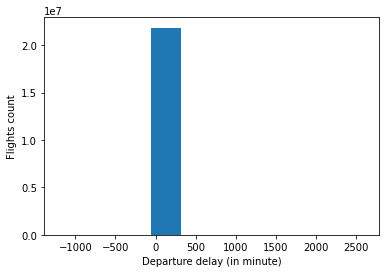

```python
plt.hist(data = flight_df, x="DepDelay")

plt.xlabel("Departure delay (in minute)")
plt.ylabel("Flights count");
```

The above plot is really uninformative. We will review its parameters in order to make a better plot. We will draw successive plots while improving them as go.

```python
# Observe the summary statistics of departure delay
flight_df["DepDelay"].describe()
```

```
count    2.185646e+07
mean     1.104316e+01
std      3.504359e+01
min     -1.200000e+03
25%     -4.000000e+00
50%      0.000000e+00
75%      1.000000e+01
max      2.601000e+03
Name: DepDelay, dtype: float64
```

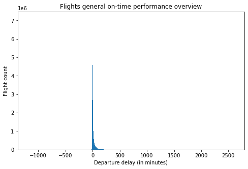

```python
binsize = 5 # bin size of 5min

min_ = -1.2e3 +10
max_ = flight_df["DepDelay"].max() + binsize

bins = np.arange(min_, max_, binsize)
#bins
plt.figure(figsize=[8,5])
plt.hist(data=flight_df, x="DepDelay", bins=bins)

plt.xlabel("Departure delay (in minutes)")
plt.ylabel("Flight count")
plt.title("Flights general on-time performance overview");
```

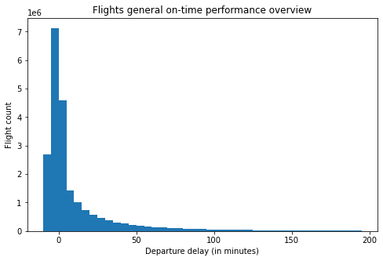

```python
# Zoom-in the x-axis (to have a better view of the data)

binsize = 5 # bin size of 5 min

min_ = -10 #-1.2e3 +100
max_ = 200 #flight_df["DepDelay"].max() + binsize

bins = np.arange(min_, max_, binsize)
#bins

plt.figure(figsize=[8,5])
plt.hist(data=flight_df, x="DepDelay", bins=bins)

plt.xlabel("Departure delay (in minutes)")
plt.ylabel("Flight count")
plt.title("Flights general on-time performance overview");
```

The data is skewed toward the right, so we will plot the distribution in a log scale instead.

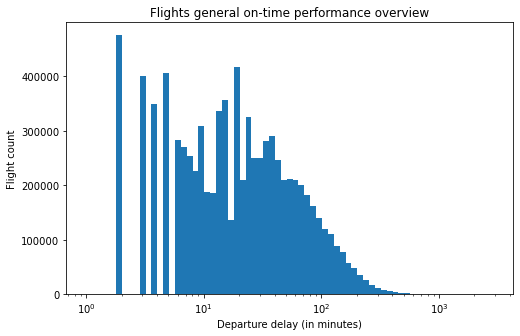

```python
# Plot in the log scale

binsize = 0.05 # bin size of 30min

min_ = 0.005 #-1.2e3 +100
max_ = np.log10(flight_df["DepDelay"].max())+ binsize # np.log10(200) # #200

bins = 10**np.arange(min_, max_, binsize)

plt.figure(figsize=[8,5])
plt.hist(data=flight_df, x="DepDelay", bins=bins)

plt.xscale("log")

plt.xlabel("Departure delay (in minutes)")
plt.ylabel("Flight count")
plt.title("Flights general on-time performance overview");
```

We have a better plot, but we will make the x-ticks label more readable.

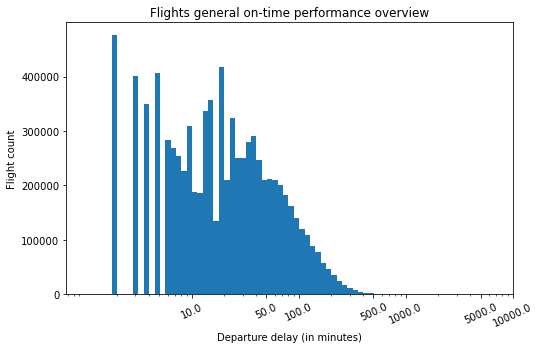

```python
# Improve the x-ticks label of the "plot in the log scale"

binsize = 0.05 # bin size of 30min

min_ = 0.005 #-1.2e3 +100
max_ = np.log10(flight_df["DepDelay"].max())+ binsize # np.log10(200) # #200

bins = 10**np.arange(min_, max_, binsize)

plt.figure(figsize=[8,5])
plt.hist(data=flight_df, x="DepDelay", bins=bins)

plt.xscale("log")

plt.xticks([10e0,10e1/2, 10e1, 10e2/2, 10e2, 10e3/2, 10e3], [10.0, 50.0, 100.0, 500.0, 1000.0, 5000.0, 10000.0],
          rotation=25)

plt.xlabel("Departure delay (in minutes)")
plt.ylabel("Flight count")
plt.title("Flights general on-time performance overview");
```

Let us zoom in the relevant part of our x-axis.

```python
10e0,10e1/2, 10e1, 10e2/2, 10e2, 10e3/2, 10e3
```

```
(10.0, 50.0, 100.0, 500.0, 1000.0, 5000.0, 10000.0)
```

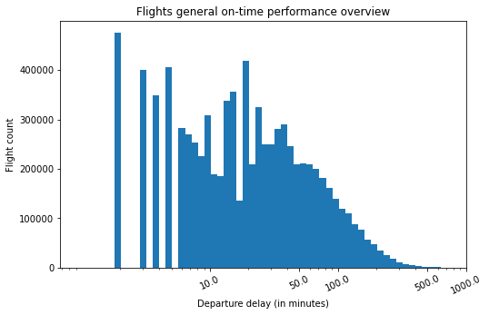

```python
# Zoom-in in the x-axis

binsize = 0.05 # bin size of 30min

min_ = 0.005 #-1.2e3 +100
max_ = np.log10(flight_df["DepDelay"].max())+ binsize # np.log10(200) # #200

bins = 10**np.arange(min_, max_, binsize)

plt.figure(figsize=[8,5])
plt.hist(data=flight_df, x="DepDelay", bins=bins)

plt.xscale("log")

plt.xticks([10e0,10e1/2, 10e1, 10e2/2, 10e2, 10e3/2, 10e3], [10.0, 50.0, 100.0, 500.0, 1000.0, 5000.0, 10000.0],
          rotation=25)

plt.xlim(0, 10e2) # Zoom-in the x-axis

plt.xlabel("Departure delay (in minutes)")
plt.ylabel("Flight count")
plt.title("Flights general on-time performance overview");
```

Now we will add more informations in the xticks labels so that we made it easier to read.

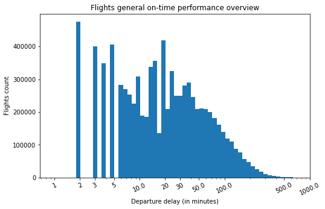

```python
# Our last and perfect plot

binsize = 0.05 # bin size of 30min

min_ = 0.005 #-1.2e3 +100
max_ = np.log10(flight_df["DepDelay"].max())+ binsize # np.log10(200) # #200

bins = 10**np.arange(min_, max_, binsize)

plt.figure(figsize=[8,5])
plt.hist(data=flight_df, x="DepDelay", bins=bins)

plt.xscale("log")

plt.xticks([1,2,3, 10e0/2, 10e0, 20, 30, 10e1/2, 10e1,  10e2/2, 10e2,   10e3/2, 10e3],
           [1,2,3, 5,      10.0, 20, 30, 50.0,   100.0, 500.0,  1000.0, 5000.0, 10000.0],
           rotation=25)

plt.xlim(0, 10e2)

plt.xlabel("Departure delay (in minutes)")
plt.ylabel("Flights count")
plt.title("Flights general on-time performance overview");
```

The standard/usual delay seems to be between 02-40 minutes. Delays over this durations are becoming less and less the further we evolve on the right side of the chart, which shows that those delays should be related to specific reasons or special cases that we will investigate later.

### Which factors are most likely to be the root of a delays ?

First things first. Since we are trying to understand the on-time performance of flights, let us first get an idea of the reasons which are most likely to make a plane being late. This may give us more idea on what to explore later.  
In order to accomplish our goal, we will retrieve a sub dataset of flights which were late on their schedule.

Recalling two features of our dataset :

- **ArrDelay**: Arrival delay of the flight, in minutes. Arrival delay equals the **difference of the actual arrival time minus the scheduled arrival time**. A flight is considered on-time when it arrives less than 15 minutes after its published arrival time.
- **DepDelay**: Departure delay of the flight, in minutes. It is the **difference between the scheduled departure time and the actual departure time** from the origin airport gate.

This mean a negative delay stand for a flight that arrived ahead of the scheduled time, while a positive delay mean a flight that is late.

```python
# datetime_str1 = "{}-{}-{} {}".format(1,21,2005,"13:05")
# date1 = datetime.strptime(datetime_str1,"%m-%d-%Y %H:%M")

# datetime_str2 = "{}-{}-{} {}".format(1,21,2005,"13:15")
# date2 = datetime.strptime(datetime_str2,"%m-%d-%Y %H:%M")
# diff = date1 - date2
# diff2 = date2-date1

# diff
```

```python
# diff.min
```

```python
# diff.total_seconds()
```

```python
# diff2.total_seconds()
```

```python
# diff.seconds
```

We will retrieve flight which arrival or departure where delayed. For the departure, we will consider 10 min as the threshold for delay.

```python
# Retrieve delayed flights data
delayed_flight_df = flight_df.query("ArrDelay >= 15 | DepDelay >= 10")
print(delayed_flight_df.shape)
delayed_flight_df.head(10).T
```

```
(6875092, 28)
```

|  | 4 | 5 | 6 | 7 | 10 | 11 | 12 | 13 | 14 | 17 |
| --- | --- | --- | --- | --- | --- | --- | --- | --- | --- | --- |
| Year | 2005 | 2005 | 2005 | 2005 | 2005 | 2005 | 2005 | 2005 | 2005 | 2005 |
| Month | 1 | 1 | 1 | 1 | 1 | 1 | 1 | 1 | 1 | 1 |
| DayofMonth | 2 | 3 | 4 | 6 | 10 | 11 | 12 | 13 | 14 | 19 |
| DayOfWeek | 7 | 1 | 2 | 4 | 1 | 2 | 3 | 4 | 5 | 3 |
| DepTime | 1934 | 2042 | 2046 | 2110 | 1917 | 1935 | 2038 | 2106 | 1919 | 1939 |
| CRSDepTime | 1900 | 1900 | 1900 | 1900 | 1900 | 1900 | 1900 | 1900 | 1900 | 1900 |
| ArrTime | 2235 | 9 | 2357 | 8 | 2240 | 2259 | 18 | 9 | 2228 | 2348 |
| CRSArrTime | 2232 | 2232 | 2232 | 2223 | 2223 | 2223 | 2223 | 2223 | 2223 | 2223 |
| UniqueCarrier | UA | UA | UA | UA | UA | UA | UA | UA | UA | UA |
| FlightNum | 542 | 542 | 542 | 542 | 542 | 542 | 542 | 542 | 542 | 542 |
| TailNum | N902UA | N904UA | N942UA | N920UA | N934UA | N336UA | N920UA | N923UA | N917UA | N932UA |
| ActualElapsedTime | 121.0 | 147.0 | 131.0 | 118.0 | 143.0 | 144.0 | 160.0 | 123.0 | 129.0 | 189.0 |
| CRSElapsedTime | 152.0 | 152.0 | 152.0 | 143.0 | 143.0 | 143.0 | 143.0 | 143.0 | 143.0 | 143.0 |
| AirTime | 106.0 | 97.0 | 100.0 | 101.0 | 116.0 | 106.0 | 111.0 | 106.0 | 100.0 | 166.0 |
| ArrDelay | 3.0 | 97.0 | 85.0 | 105.0 | 17.0 | 36.0 | 115.0 | 106.0 | 5.0 | 85.0 |
| DepDelay | 34.0 | 102.0 | 106.0 | 130.0 | 17.0 | 35.0 | 98.0 | 126.0 | 19.0 | 39.0 |
| Origin | ORD | ORD | ORD | ORD | ORD | ORD | ORD | ORD | ORD | ORD |
| Dest | BOS | BOS | BOS | BOS | BOS | BOS | BOS | BOS | BOS | BOS |
| Distance | 867 | 867 | 867 | 867 | 867 | 867 | 867 | 867 | 867 | 867 |
| TaxiIn | 5.0 | 3.0 | 5.0 | 2.0 | 3.0 | 6.0 | 6.0 | 6.0 | 9.0 | 6.0 |
| TaxiOut | 10.0 | 47.0 | 26.0 | 15.0 | 24.0 | 32.0 | 43.0 | 11.0 | 20.0 | 17.0 |
| Cancelled | 0 | 0 | 0 | 0 | 0 | 0 | 0 | 0 | 0 | 0 |
| Diverted | 0 | 0 | 0 | 0 | 0 | 0 | 0 | 0 | 0 | 0 |
| CarrierDelay | 0.0 | 23.0 | 46.0 | 16.0 | 17.0 | 0.0 | 18.0 | 13.0 | 0.0 | 10.0 |
| WeatherDelay | 0.0 | 0.0 | 0.0 | 0.0 | 0.0 | 0.0 | 0.0 | 0.0 | 0.0 | 0.0 |
| NASDelay | 0.0 | 0.0 | 0.0 | 0.0 | 0.0 | 1.0 | 17.0 | 0.0 | 0.0 | 46.0 |
| SecurityDelay | 0.0 | 0.0 | 0.0 | 0.0 | 0.0 | 0.0 | 0.0 | 0.0 | 0.0 | 0.0 |
| LateAircraftDelay | 0.0 | 74.0 | 39.0 | 89.0 | 0.0 | 35.0 | 80.0 | 93.0 | 0.0 | 29.0 |

We have 5 delays reason:

- **CarrierDelay**: In minutes. Carrier delay record the delays that are within the control of the air carrier. Examples of occurrences that may determine carrier delay are: aircraft cleaning, aircraft damage, awaiting the arrival of connecting passengers or crew, baggage, bird strike, cargo loading, catering, computer, outage-carrier equipment, crew legality (pilot or attendant rest), damage by hazardous goods, engineering inspection, fueling, handling disabled passengers, late crew, lavatory servicing, maintenance, oversales, potable water servicing, removal of unruly passenger, slow boarding or seating, stowing carry-on baggage, weight and balance delays.
- **WeatherDelay**: In minutes. Weather delay is caused by extreme or hazardous weather conditions that are forecasted or manifest themselves on point of departure, enroute, or on point of arrival.
- **NASDelay**: In minutes. Delay that is within the control of the National Airspace System (NAS) may include: non-extreme weather conditions, airport operations, heavy traffic volume, air traffic control, etc.
- **SecurityDelay**: In minutes. Security delay is caused by evacuation of a terminal or concourse, re-boarding of aircraft because of security breach, inoperative screening equipment and/or long lines in excess of 29 minutes at screening areas.
- **LateAircraftDelay** in minutes: Arrival delay at an airport due to the late arrival of the same aircraft at a previous airport. The ripple effect of an earlier delay at downstream airports is referred to as delay propagation.
- **OtherDelay** in minutes : Delays which are not part of the above mentioned ones.

We will work based those variables.

```python
# .groupby(["CarrierDelay","WeatherDelay","NASDelay",
#                                                       "SecurityDelay","LateAircraftDelay"]) \
```

```python
delay_variables = ["CarrierDelay","WeatherDelay","NASDelay", "SecurityDelay","LateAircraftDelay"]
delay_variables
```

```
['CarrierDelay',
 'WeatherDelay',
 'NASDelay',
 'SecurityDelay',
 'LateAircraftDelay']
```

```python
delayed_flight_df["OtherDelay"] = delayed_flight_df["DepDelay"] - delayed_flight_df[delay_variables].sum(axis=1)
delayed_flight_df[["DepDelay"]+delay_variables+["OtherDelay"]].head(15).T
```

|  | 4 | 5 | 6 | 7 | 10 | 11 | 12 | 13 | 14 | 17 | 18 | 19 | 27 | 28 | 29 |
| --- | --- | --- | --- | --- | --- | --- | --- | --- | --- | --- | --- | --- | --- | --- | --- |
| DepDelay | 34.0 | 102.0 | 106.0 | 130.0 | 17.0 | 35.0 | 98.0 | 126.0 | 19.0 | 39.0 | 148.0 | 13.0 | 101.0 | 29.0 | 221.0 |
| CarrierDelay | 0.0 | 23.0 | 46.0 | 16.0 | 17.0 | 0.0 | 18.0 | 13.0 | 0.0 | 10.0 | 32.0 | 0.0 | 0.0 | 0.0 | 0.0 |
| WeatherDelay | 0.0 | 0.0 | 0.0 | 0.0 | 0.0 | 0.0 | 0.0 | 0.0 | 0.0 | 0.0 | 0.0 | 0.0 | 0.0 | 0.0 | 0.0 |
| NASDelay | 0.0 | 0.0 | 0.0 | 0.0 | 0.0 | 1.0 | 17.0 | 0.0 | 0.0 | 46.0 | 0.0 | 0.0 | 111.0 | 35.0 | 199.0 |
| SecurityDelay | 0.0 | 0.0 | 0.0 | 0.0 | 0.0 | 0.0 | 0.0 | 0.0 | 0.0 | 0.0 | 0.0 | 0.0 | 0.0 | 0.0 | 0.0 |
| LateAircraftDelay | 0.0 | 74.0 | 39.0 | 89.0 | 0.0 | 35.0 | 80.0 | 93.0 | 0.0 | 29.0 | 106.0 | 0.0 | 0.0 | 0.0 | 0.0 |
| OtherDelay | 34.0 | 5.0 | 21.0 | 25.0 | 0.0 | -1.0 | -17.0 | 20.0 | 19.0 | -46.0 | 10.0 | 13.0 | -10.0 | -6.0 | 22.0 |

```python
delay_variables+=["OtherDelay"]
delay_variables
```

```
['CarrierDelay',
 'WeatherDelay',
 'NASDelay',
 'SecurityDelay',
 'LateAircraftDelay',
 'OtherDelay']
```

```python
delayed_flight_df[["DepDelay"]+delay_variables].describe()
```

|  | DepDelay | CarrierDelay | WeatherDelay | NASDelay | SecurityDelay | LateAircraftDelay | OtherDelay |
| --- | --- | --- | --- | --- | --- | --- | --- |
| count | 6.875092e+06 | 6.875092e+06 | 6.875092e+06 | 6.875092e+06 | 6.875092e+06 | 6.875092e+06 | 6.875092e+06 |
| mean | 3.981223e+01 | 1.217643e+01 | 2.476304e+00 | 1.269850e+01 | 8.528715e-02 | 1.580643e+01 | -3.430730e+00 |
| std | 5.152879e+01 | 3.476052e+01 | 1.657026e+01 | 2.732032e+01 | 2.077138e+00 | 3.455902e+01 | 2.234997e+01 |
| min | -1.200000e+03 | 0.000000e+00 | 0.000000e+00 | -4.900000e+01 | 0.000000e+00 | 0.000000e+00 | -1.602000e+03 |
| 25% | 1.200000e+01 | 0.000000e+00 | 0.000000e+00 | 0.000000e+00 | 0.000000e+00 | 0.000000e+00 | -1.400000e+01 |
| 50% | 2.400000e+01 | 0.000000e+00 | 0.000000e+00 | 0.000000e+00 | 0.000000e+00 | 0.000000e+00 | 1.000000e+00 |
| 75% | 5.000000e+01 | 1.100000e+01 | 0.000000e+00 | 1.600000e+01 | 0.000000e+00 | 1.800000e+01 | 1.100000e+01 |
| max | 2.601000e+03 | 2.580000e+03 | 1.510000e+03 | 1.392000e+03 | 3.920000e+02 | 1.366000e+03 | 2.250000e+02 |

The negative value of `OtherDelay` should be related to how `DepDelay` and the other delay reasons are computed (rounded); say delay can be recored by increment of 5min, otherwise 0 will be applied.  
Since we don't know the specific rules to record each delay reason, we will avoid using `OtherDelay` in our analyzes.  
We will record the case here as a limitation in our work.

```python
# Remove "OtherDelay" from our variables

print(delayed_flight_df.shape)
delayed_flight_df.drop(["OtherDelay"],axis=1,inplace=True)
delayed_flight_df.shape
```

```
(6875092, 29)
```

```
(6875092, 28)
```

```python
delay_variables.remove("OtherDelay")
```

```python
# Compute the sum of delays per reason
sum_of_delays_per_reason = delayed_flight_df[delay_variables] \
                          .sum() \
                          .sort_values(ascending=False)
sum_of_delays_per_reason
```

```
LateAircraftDelay    108670643.0
NASDelay              87303386.0
CarrierDelay          83714095.0
WeatherDelay          17024820.0
SecurityDelay           586357.0
dtype: float64
```

We can see that :

- Most delays result from the ripple effect (late arrival of the same aircraft at a previous airport).
- A fair amount of delays are also related to National Airspace System (NAS) and to the carrier itself.
- Delays related to security issues are little.

A plot will help us better observe how delays are distributed over reasons.

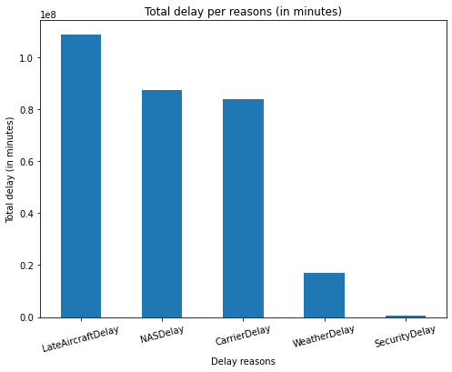

```python
# Plot the sum of delays per reason
sum_of_delays_per_reason.plot(kind="bar", figsize=(8,6))

plt.xlabel("Delay reasons")
plt.ylabel("Total delay (in minutes)")
plt.title("Total delay per reasons (in minutes)")

plt.xticks(rotation=15);
```

We can observe from the plot that :

- Most delays are related to the ripple effect
- NAS and the carrier itself are the next two reasons that induce delays
- Delays related to weather are minor, while delays related to security are practically non-existent

From those observations, we can have some sligh conclusions :

- It is possible to forcast the weather most of the time, so the flights schedule are done accordingly
- A plane being late on a schedule likely mean its previous flight was delayed (ripple effect)
- The root of a ripple effect (the first delay of the plane) should be related to NAS and/or carrier operations (cleaning, cargo loading, ...)

### How much should someone expect to way at an airport because of flight delay ?

We want to know here how much should someone expect to be delayed in general, and how much he should expect to be delayed because of a particular reason.

```python
delayed_flight_df.head(5).T
```

|  | 4 | 5 | 6 | 7 | 10 |
| --- | --- | --- | --- | --- | --- |
| Year | 2005 | 2005 | 2005 | 2005 | 2005 |
| Month | 1 | 1 | 1 | 1 | 1 |
| DayofMonth | 2 | 3 | 4 | 6 | 10 |
| DayOfWeek | 7 | 1 | 2 | 4 | 1 |
| DepTime | 1934 | 2042 | 2046 | 2110 | 1917 |
| CRSDepTime | 1900 | 1900 | 1900 | 1900 | 1900 |
| ArrTime | 2235 | 9 | 2357 | 8 | 2240 |
| CRSArrTime | 2232 | 2232 | 2232 | 2223 | 2223 |
| UniqueCarrier | UA | UA | UA | UA | UA |
| FlightNum | 542 | 542 | 542 | 542 | 542 |
| TailNum | N902UA | N904UA | N942UA | N920UA | N934UA |
| ActualElapsedTime | 121.0 | 147.0 | 131.0 | 118.0 | 143.0 |
| CRSElapsedTime | 152.0 | 152.0 | 152.0 | 143.0 | 143.0 |
| AirTime | 106.0 | 97.0 | 100.0 | 101.0 | 116.0 |
| ArrDelay | 3.0 | 97.0 | 85.0 | 105.0 | 17.0 |
| DepDelay | 34.0 | 102.0 | 106.0 | 130.0 | 17.0 |
| Origin | ORD | ORD | ORD | ORD | ORD |
| Dest | BOS | BOS | BOS | BOS | BOS |
| Distance | 867 | 867 | 867 | 867 | 867 |
| TaxiIn | 5.0 | 3.0 | 5.0 | 2.0 | 3.0 |
| TaxiOut | 10.0 | 47.0 | 26.0 | 15.0 | 24.0 |
| Cancelled | 0 | 0 | 0 | 0 | 0 |
| Diverted | 0 | 0 | 0 | 0 | 0 |
| CarrierDelay | 0.0 | 23.0 | 46.0 | 16.0 | 17.0 |
| WeatherDelay | 0.0 | 0.0 | 0.0 | 0.0 | 0.0 |
| NASDelay | 0.0 | 0.0 | 0.0 | 0.0 | 0.0 |
| SecurityDelay | 0.0 | 0.0 | 0.0 | 0.0 | 0.0 |
| LateAircraftDelay | 0.0 | 74.0 | 39.0 | 89.0 | 0.0 |

We will know how much should someone expect to be delayed in general by referring to the mean delay.  
We will use the delay reasons instead of `DepDelay` to work in order to keep the result consistent with "the mean delay per reason".

```python
# General mean delay of a flight
mean_of_delays = delayed_flight_df[delay_variables].sum(axis=1).mean()
mean_of_delays
```

```
43.24295602153396
```

```python
# General mean delay of a flight per reason
mean_of_delays_per_reason = delayed_flight_df[delay_variables].mean().sort_values(ascending=False)
mean_of_delays_per_reason
```

```
LateAircraftDelay    15.806427
NASDelay             12.698504
CarrierDelay         12.176433
WeatherDelay          2.476304
SecurityDelay         0.085287
dtype: float64
```

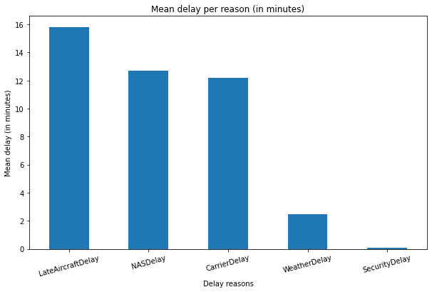

```python
# Plot general mean delay of a flight per reason
mean_of_delays_per_reason.plot(kind="bar", figsize=(10,6))

plt.xlabel("Delay reasons")
plt.ylabel("Mean delay (in minutes)")
plt.title("Mean delay per reason (in minutes)")

plt.xticks(rotation=15);
```

We can conclude from our analysis here that if all pre-flight activities are conducted in parallel, we can expect a flight to be late by as much as 16min; while we should expect a delay of about 40min if pre-flight activities are conducted sequenctially.

Now let us try to understand if there is a relationship between delay and origin airport.

### Is there a relationship between delay and origin airport ?

We are interested in how delays are distributed over origin airports. We wish to know if each airport performs approximatively the same, or if there are diffenre in performance.

We will answer this question by understanding the mean delay per airport.

```python
# Mean delay per airport
mean_delay_per_origin = delayed_flight_df[["DepDelay","Origin"]].groupby(["Origin"]).mean() \
                                                                  .sort_values(by="DepDelay",ascending=False)

mean_delay_per_origin
```

| Origin | DepDelay |
| --- | --- |
| CMX | 134.542373 |
| OGD | 108.000000 |
| CYS | 105.000000 |
| ALO | 85.742424 |
| PLN | 80.426667 |
| ... | ... |
| RFD | 28.982332 |
| VIS | 19.280702 |
| YKM | 18.587500 |
| RKS | 16.900000 |
| MKC | 8.000000 |

315 rows × 1 columns

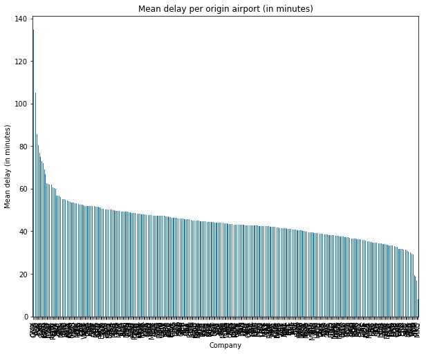

```python
# Plot mean delay per airport
mean_delay_per_origin.plot(kind="bar", figsize=(10,8))

plt.xlabel("Company")
plt.ylabel("Mean delay (in minutes)")

plt.legend("", frameon=False) # Remove legend

plt.title("Mean delay per origin airport (in minutes)");
```

Despite the fact that the above plot doesn't tell us much about the concerned airports, it still allows us to see that there are airports which perform better than other. There are airport where delays revolve under 25-30 min, while there are other where delays are higher than 60min.  
So we can conclude here that **knowing the origin airport plays a role in knowing weither a flight will be late or not.**

With that knowledge, we will now explore which airports perform better and which ones perform the worst.

### How does airports perform compared to each others ?

We will observe the airports which have less delay and the ones which have most delay.  
The first step will be to add more information to our `mean_delay_per_origin` dataframe, so that we put the real name of the airports (and not their acronym) in our charts.  
Then we will make our plots.

```python
mean_delay_per_origin
```

| Origin | DepDelay |
| --- | --- |
| CMX | 134.542373 |
| OGD | 108.000000 |
| CYS | 105.000000 |
| ALO | 85.742424 |
| PLN | 80.426667 |
| ... | ... |
| RFD | 28.982332 |
| VIS | 19.280702 |
| YKM | 18.587500 |
| RKS | 16.900000 |
| MKC | 8.000000 |

315 rows × 1 columns

```python
# Make the index become a column
mean_delay_per_origin.reset_index(inplace=True)
mean_delay_per_origin
```

|  | Origin | DepDelay |
| --- | --- | --- |
| 0 | CMX | 134.542373 |
| 1 | OGD | 108.000000 |
| 2 | CYS | 105.000000 |
| 3 | ALO | 85.742424 |
| 4 | PLN | 80.426667 |
| ... | ... | ... |
| 310 | RFD | 28.982332 |
| 311 | VIS | 19.280702 |
| 312 | YKM | 18.587500 |
| 313 | RKS | 16.900000 |
| 314 | MKC | 8.000000 |

315 rows × 2 columns

```python
airport_df.head()
```

|  | iata | airport | city | state | country | lat | long |
| --- | --- | --- | --- | --- | --- | --- | --- |
| 0 | 00M | Thigpen | Bay Springs | MS | USA | 31.953765 | -89.234505 |
| 1 | 00R | Livingston Municipal | Livingston | TX | USA | 30.685861 | -95.017928 |
| 2 | 00V | Meadow Lake | Colorado Springs | CO | USA | 38.945749 | -104.569893 |
| 3 | 01G | Perry-Warsaw | Perry | NY | USA | 42.741347 | -78.052081 |
| 4 | 01J | Hilliard Airpark | Hilliard | FL | USA | 30.688012 | -81.905944 |

```python
mean_delay_per_origin = mean_delay_per_origin.merge(airport_df, how="inner", left_on="Origin", right_on="iata")
mean_delay_per_origin
```

|  | Origin | DepDelay | iata | airport | city | state | country | lat | long |
| --- | --- | --- | --- | --- | --- | --- | --- | --- | --- |
| 0 | CMX | 134.542373 | CMX | Houghton County Memorial | Hancock | MI | USA | 47.168417 | -88.489061 |
| 1 | OGD | 108.000000 | OGD | Ogden-Hinckley | Ogden | UT | USA | 41.195944 | -112.012175 |
| 2 | CYS | 105.000000 | CYS | Cheyenne | Cheyenne | WY | USA | 41.155723 | -104.811838 |
| 3 | ALO | 85.742424 | ALO | Waterloo Municipal | Waterloo | IA | USA | 42.557081 | -92.400344 |
| 4 | PLN | 80.426667 | PLN | Pellston Regional of Emmet County | Pellston | MI | USA | 45.570928 | -84.796715 |
| ... | ... | ... | ... | ... | ... | ... | ... | ... | ... |
| 310 | RFD | 28.982332 | RFD | Greater Rockford | Rockford | IL | USA | 42.195364 | -89.097211 |
| 311 | VIS | 19.280702 | VIS | Visalia Municipal | Visalia | CA | USA | 36.318667 | -119.392889 |
| 312 | YKM | 18.587500 | YKM | Yakima Air Terminal | Yakima | WA | USA | 46.568170 | -120.544059 |
| 313 | RKS | 16.900000 | RKS | Rock Springs-Sweetwater County | Rock Springs | WY | USA | 41.594217 | -109.065193 |
| 314 | MKC | 8.000000 | MKC | Downtown | Kansas City | MO | USA | 39.123241 | -94.592735 |

315 rows × 9 columns

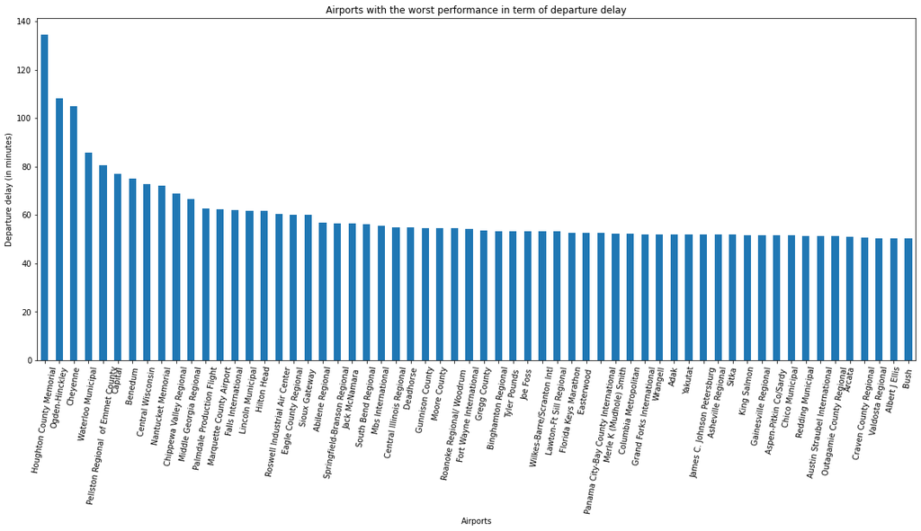

```python
# Plot the top airports which have the worst performance in term of departure delay

mean_delay_per_origin.iloc[:60,:].plot(kind="bar",x="airport",y="DepDelay", figsize=(20,8))

plt.legend("", frameon=False) # Remove legend

plt.xlabel("Airports")
plt.ylabel("Departure delay (in minutes)")
plt.title("Airports with the worst performance in term of departure delay")

plt.xticks(rotation=80);
```

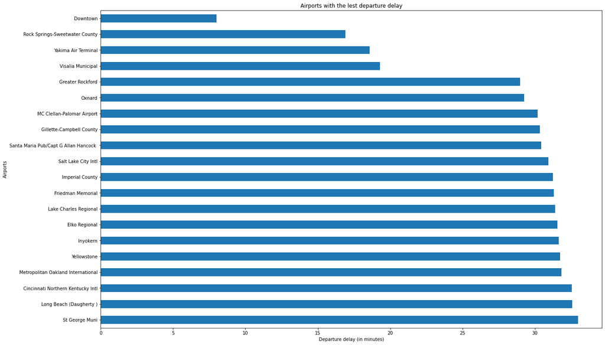

```python
# Plot the airports which have the lest departure delay

# mean_delay_per_origin.iloc[-60:,:].plot(kind="bar",x="airport",y="DepDelay", figsize=(20,8))
# plt.xlabel("Airports")
# plt.ylabel("Departure delay (in minutes)")

mean_delay_per_origin.iloc[-20:,:].plot(kind="barh",x="airport",y="DepDelay", figsize=(20,13))

plt.legend("", frameon=False) # Remove legend

plt.xlabel("Departure delay (in minutes)")
plt.ylabel("Airports")

plt.title("Airports with the lest departure delay");

# plt.xticks(rotation=85);
```

In general, we should expect a delay of around 30min in the airports that have the less delay.  
The 03 best airports between those which tend to have the less delay have a delay starting from about 08minutes to less than 20min.

### Does departure delay imperatively imply arrival delay ?

The theoretic answer is yes, but we will still confirm it to be sure of things.

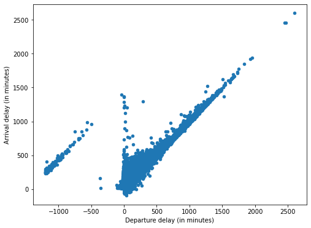

```python
delayed_flight_df.plot(kind="scatter",x="DepDelay",y="ArrDelay", figsize=(8,6))

plt.xlabel("Departure delay (in minutes)")
plt.ylabel("Arrival delay (in minutes)");
```

We are observing a linear relationship in the above plot. It tells that a departure delay has impacts on arrival delay.  
Let's make use of a better plot to see if we can gain more insights from it.

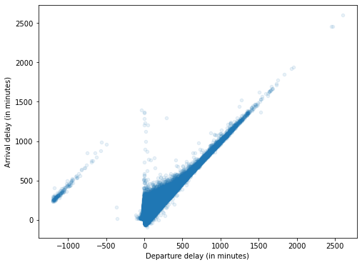

```python
delayed_flight_df.plot(kind="scatter",x="DepDelay",y="ArrDelay", figsize=(8,6), alpha=1/10)

plt.xlabel("Departure delay (in minutes)")
plt.ylabel("Arrival delay (in minutes)");
```

It appears from this plot that the departure delay is roughly equal to the arrival delay. So we don't need to dwell to much in the arrival delay analysis, we can focuse our investigation on departure delay.

### Is there a relationship between on-time performance and plane ?

In order to answer this question:

- We will consider the whole flight's dataset; we will no more exclude this time the flights on-time.
- We will retrieve the mean departure delay per plane, and plot it.

```python
flight_df.head(5).T
```

|  | 0 | 1 | 2 | 3 | 4 |
| --- | --- | --- | --- | --- | --- |
| Year | 2005 | 2005 | 2005 | 2005 | 2005 |
| Month | 1 | 1 | 1 | 1 | 1 |
| DayofMonth | 28 | 29 | 30 | 31 | 2 |
| DayOfWeek | 5 | 6 | 7 | 1 | 7 |
| DepTime | 1603 | 1559 | 1603 | 1556 | 1934 |
| CRSDepTime | 1605 | 1605 | 1610 | 1605 | 1900 |
| ArrTime | 1741 | 1736 | 1741 | 1726 | 2235 |
| CRSArrTime | 1759 | 1759 | 1805 | 1759 | 2232 |
| UniqueCarrier | UA | UA | UA | UA | UA |
| FlightNum | 541 | 541 | 541 | 541 | 542 |
| TailNum | N935UA | N941UA | N342UA | N326UA | N902UA |
| ActualElapsedTime | 158.0 | 157.0 | 158.0 | 150.0 | 121.0 |
| CRSElapsedTime | 174.0 | 174.0 | 175.0 | 174.0 | 152.0 |
| AirTime | 131.0 | 136.0 | 131.0 | 129.0 | 106.0 |
| ArrDelay | -18.0 | -23.0 | -24.0 | -33.0 | 3.0 |
| DepDelay | -2.0 | -6.0 | -7.0 | -9.0 | 34.0 |
| Origin | BOS | BOS | BOS | BOS | ORD |
| Dest | ORD | ORD | ORD | ORD | BOS |
| Distance | 867 | 867 | 867 | 867 | 867 |
| TaxiIn | 4.0 | 6.0 | 9.0 | 11.0 | 5.0 |
| TaxiOut | 23.0 | 15.0 | 18.0 | 10.0 | 10.0 |
| Cancelled | 0 | 0 | 0 | 0 | 0 |
| Diverted | 0 | 0 | 0 | 0 | 0 |
| CarrierDelay | 0.0 | 0.0 | 0.0 | 0.0 | 0.0 |
| WeatherDelay | 0.0 | 0.0 | 0.0 | 0.0 | 0.0 |
| NASDelay | 0.0 | 0.0 | 0.0 | 0.0 | 0.0 |
| SecurityDelay | 0.0 | 0.0 | 0.0 | 0.0 | 0.0 |
| LateAircraftDelay | 0.0 | 0.0 | 0.0 | 0.0 | 0.0 |

```python
delay_variables
```

```
['CarrierDelay',
 'WeatherDelay',
 'NASDelay',
 'SecurityDelay',
 'LateAircraftDelay']
```

```python
mean_delay_per_plane = flight_df.groupby(["TailNum"])   \
                                .mean()   \
                                .loc[:,["DepDelay"]+delay_variables] \
                                .sort_values(by="DepDelay", ascending=False)
mean_delay_per_plane
```

| TailNum | DepDelay | CarrierDelay | WeatherDelay | NASDelay | SecurityDelay | LateAircraftDelay |
| --- | --- | --- | --- | --- | --- | --- |
| N163AT | 300.000000 | 150.000000 | 0.000000 | 0.000000 | 0.000000 | 147.500000 |
| N852NW | 259.250000 | 157.750000 | 0.000000 | 5.250000 | 0.000000 | 94.500000 |
| N161AT | 212.500000 | 107.000000 | 0.000000 | 7.500000 | 0.000000 | 92.500000 |
| N194JB | 180.000000 | 0.000000 | 0.000000 | 54.000000 | 0.000000 | 134.000000 |
| N713TW | 164.666667 | 143.000000 | 0.000000 | 0.000000 | 0.000000 | 13.333333 |
| ... | ... | ... | ... | ... | ... | ... |
| N477HA | -2.786660 | 0.449908 | 0.012096 | 0.021299 | 0.001665 | 0.369270 |
| N481HA | -2.801640 | 0.484937 | 0.012085 | 0.018127 | 0.001640 | 0.437894 |
| N480HA | -2.810767 | 0.466362 | 0.014030 | 0.016058 | 0.000845 | 0.546484 |
| N479HA | -2.984971 | 0.378362 | 0.005807 | 0.018017 | 0.000000 | 0.335155 |
| N306TZ | -3.375000 | 0.000000 | 0.000000 | 0.000000 | 0.000000 | 0.000000 |

6270 rows × 6 columns

```python
mean_delay_per_plane.rename(columns={
    "DepDelay":"MeanDepDelay",
    "CarrierDelay": "MeanCarrierDelay",
    "WeatherDelay": "MeanWeatherDelay",
    "NASDelay":"MeanNASDelay",
    "SecurityDelay" : "MeanSecurityDelay",
    "LateAircraftDelay": "MeanLateAircraftDelay"
},inplace=True)
mean_delay_per_plane.head()
```

| TailNum | MeanDepDelay | MeanCarrierDelay | MeanWeatherDelay | MeanNASDelay | MeanSecurityDelay | MeanLateAircraftDelay |
| --- | --- | --- | --- | --- | --- | --- |
| N163AT | 300.000000 | 150.00 | 0.0 | 0.00 | 0.0 | 147.500000 |
| N852NW | 259.250000 | 157.75 | 0.0 | 5.25 | 0.0 | 94.500000 |
| N161AT | 212.500000 | 107.00 | 0.0 | 7.50 | 0.0 | 92.500000 |
| N194JB | 180.000000 | 0.00 | 0.0 | 54.00 | 0.0 | 134.000000 |
| N713TW | 164.666667 | 143.00 | 0.0 | 0.00 | 0.0 | 13.333333 |

There are plane which tend to perform as good as depart 03-04 minutes before the scheduled time while there are planes which tend to perform so badly as to have delay between 160-300 minutes.  
It seem that we now have a good lead to understand a factor that can also be in our control apart from the choosen airport. But before going further, let us plot our data.

```python
# Reset the index so that we have plane tail number as a column
mean_delay_per_plane.reset_index(inplace=True)
mean_delay_per_plane
```

|  | TailNum | MeanDepDelay | MeanCarrierDelay | MeanWeatherDelay | MeanNASDelay | MeanSecurityDelay | MeanLateAircraftDelay |
| --- | --- | --- | --- | --- | --- | --- | --- |
| 0 | N163AT | 300.000000 | 150.000000 | 0.000000 | 0.000000 | 0.000000 | 147.500000 |
| 1 | N852NW | 259.250000 | 157.750000 | 0.000000 | 5.250000 | 0.000000 | 94.500000 |
| 2 | N161AT | 212.500000 | 107.000000 | 0.000000 | 7.500000 | 0.000000 | 92.500000 |
| 3 | N194JB | 180.000000 | 0.000000 | 0.000000 | 54.000000 | 0.000000 | 134.000000 |
| 4 | N713TW | 164.666667 | 143.000000 | 0.000000 | 0.000000 | 0.000000 | 13.333333 |
| ... | ... | ... | ... | ... | ... | ... | ... |
| 6265 | N477HA | -2.786660 | 0.449908 | 0.012096 | 0.021299 | 0.001665 | 0.369270 |
| 6266 | N481HA | -2.801640 | 0.484937 | 0.012085 | 0.018127 | 0.001640 | 0.437894 |
| 6267 | N480HA | -2.810767 | 0.466362 | 0.014030 | 0.016058 | 0.000845 | 0.546484 |
| 6268 | N479HA | -2.984971 | 0.378362 | 0.005807 | 0.018017 | 0.000000 | 0.335155 |
| 6269 | N306TZ | -3.375000 | 0.000000 | 0.000000 | 0.000000 | 0.000000 | 0.000000 |

6270 rows × 7 columns

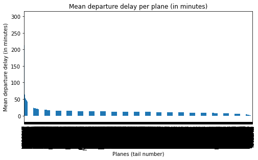

```python
mean_delay_per_plane.plot(kind="bar",x="TailNum",y="MeanDepDelay", figsize=(8,4))

plt.xlabel("Planes (tail number)")
plt.ylabel("Mean departure delay (in minutes)")
plt.title("Mean departure delay per plane (in minutes)")

plt.legend("", frameon=False) # Remove legend;
```

The plot doesn't give us much information (we can only see a smooth decrease of departure delay, except for the first planes which has a high departure delay); however, it still tell orient us to investigate three part of our data:

- the first 100 planes (they have the worst on-time performance)
- the last 100 planes (they have the best on-time performance)
- the middle 100 planes (they will stand for the planes with an average on-time performance, since all planes apart from those in the spectrum seem to have the same average on-time performance)

```python
# Worst 100 performing planes
worst_performing_planes_df = mean_delay_per_plane.iloc[:100,:]
worst_performing_planes_df
```

|  | TailNum | MeanDepDelay |
| --- | --- | --- |
| 0 | N163AT | 300.000000 |
| 1 | N852NW | 259.250000 |
| 2 | N161AT | 212.500000 |
| 3 | N194JB | 180.000000 |
| 4 | N713TW | 164.666667 |
| ... | ... | ... |
| 95 | N37419 | 40.440000 |
| 96 | N902WN | 39.972851 |
| 97 | N273AE | 39.423077 |
| 98 | N905WN | 39.408333 |
| 99 | N805NW | 39.408163 |

100 rows × 2 columns

The top worst performing planes have a mean departure delay :

- Going from 160 minutes to 300 minutes at the top
- Ranging from 39 minutes to 40 minutes at the bottom.

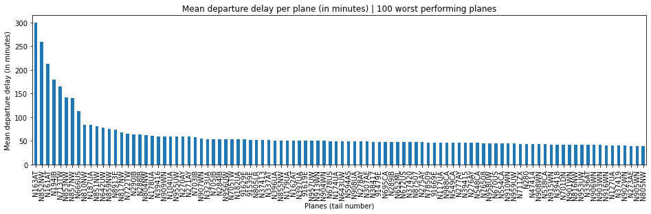

```python
# Plot the 100 worst performing planes
worst_performing_planes_df.plot(kind="bar",x="TailNum",y="MeanDepDelay", figsize=(16,4))

plt.xlabel("Planes (tail number)")
plt.ylabel("Mean departure delay (in minutes)")
plt.title("Mean departure delay per plane (in minutes) | 100 worst performing planes")

plt.legend("", frameon=False); # Remove legend;
```

We can see that other than the first 10 or so planes which as a higher mean departure delay, the following planes has lower and nearly the same departure delays.

```python
# 100 best performing planes
worst_performing_planes_df = mean_delay_per_plane.iloc[-100:,:]
worst_performing_planes_df
```

|  | TailNum | MeanDepDelay |
| --- | --- | --- |
| 6170 | N9347 | 2.197917 |
| 6171 | N308WA | 2.182583 |
| 6172 | N231DN | 2.151109 |
| 6173 | N827AL | 2.078947 |
| 6174 | N242DL | 2.060255 |
| ... | ... | ... |
| 6265 | N477HA | -2.786660 |
| 6266 | N481HA | -2.801640 |
| 6267 | N480HA | -2.810767 |
| 6268 | N479HA | -2.984971 |
| 6269 | N306TZ | -3.375000 |

100 rows × 2 columns

The best perfoming planes has a departure delay of 02 minutes at worst. And there are plane which go as far as tending to take-off 02 to 03 minutes before the scheduled time.

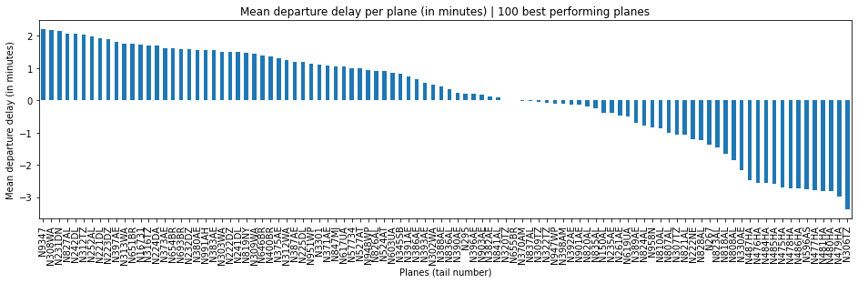

```python
# Plot the 100 best performing planes
worst_performing_planes_df.plot(kind="bar",x="TailNum",y="MeanDepDelay", figsize=(16,4))

plt.xlabel("Planes (tail number)")
plt.ylabel("Mean departure delay (in minutes)")
plt.title("Mean departure delay per plane (in minutes) | 100 best performing planes")

plt.legend("", frameon=False) # Remove legend;
```

The further we go on the spectrum, the better on-time performance the planes have.

```python
# Looking at the number of planes we have, so that we know which indexes to select for those in the middle
mean_delay_per_plane.count()
```

```
TailNum         6270
MeanDepDelay    6270
dtype: int64
```

```python
# 100 medium performing planes
medium_performing_planes_df = mean_delay_per_plane.iloc[3100:3200,:]
medium_performing_planes_df
```

|  | TailNum | MeanDepDelay |
| --- | --- | --- |
| 3100 | N16149 | 11.431225 |
| 3101 | N340NW | 11.430437 |
| 3102 | N315US | 11.430084 |
| 3103 | N214WN | 11.427840 |
| 3104 | N409WN | 11.425581 |
| ... | ... | ... |
| 3195 | N210WN | 11.299363 |
| 3196 | N254 | 11.298981 |
| 3197 | N825AE | 11.295949 |
| 3198 | N402UA | 11.295191 |
| 3199 | N926DL | 11.293474 |

100 rows × 2 columns

The medium performing planes have the same mean departure delay, which is 11-12 minutes.

[figure not shown]

```python
# Plot the 100 medium performing planes
medium_performing_planes_df.plot(kind="bar",x="TailNum",y="MeanDepDelay", figsize=(16,4))

plt.xlabel("Planes (tail number)")
plt.ylabel("Mean departure delay (in minutes)")
plt.title("Mean departure delay per plane (in minutes) | 100 medium performing planes")

plt.legend("", frameon=False) # Remove legend;
```

Those planes have the same average departure delay.

Based on the previous 03 plots, we can confirm that planes are definitly playing a role in departure delays. Let us investigate the reason behind this. The possible factors that can delays flight are :

- plane age (maybe the older the plane, the longer it take to make it ready to take-off)
- number of seat in the plane (maybe the greater the number of seats, the higher the time needed by the passenger to on-board is)
- distance traveled by the plane (maybe the greater the distance, the longer the pre-flights operations are)

We will investigate each of these cases.

```python
# plt.hist(data=mean_delay_per_plane, x="TailNum",height="DepDelay")
```

### Is there a relationship between a plane's age and its departure delay ?

We are trying to understand if the older the age, the longer its departure delay.

```python
mean_delay_per_plane.head()
```

|  | TailNum | MeanDepDelay |
| --- | --- | --- |
| 0 | N163AT | 300.000000 |
| 1 | N852NW | 259.250000 |
| 2 | N161AT | 212.500000 |
| 3 | N194JB | 180.000000 |
| 4 | N713TW | 164.666667 |

We will first assess the content and structure of `plane_df`

```python
plane_df.head()
```

|  | tailnum | type | manufacturer | issue_date | model | status | aircraft_type | engine_type | year |
| --- | --- | --- | --- | --- | --- | --- | --- | --- | --- |
| 0 | N050AA | NaN | NaN | NaN | NaN | NaN | NaN | NaN | NaN |
| 1 | N051AA | NaN | NaN | NaN | NaN | NaN | NaN | NaN | NaN |
| 2 | N052AA | NaN | NaN | NaN | NaN | NaN | NaN | NaN | NaN |
| 3 | N054AA | NaN | NaN | NaN | NaN | NaN | NaN | NaN | NaN |
| 4 | N055AA | NaN | NaN | NaN | NaN | NaN | NaN | NaN | NaN |

```python
plane_df.info()
```

```
<class 'pandas.core.frame.DataFrame'>
RangeIndex: 5029 entries, 0 to 5028
Data columns (total 9 columns):
 #   Column         Non-Null Count  Dtype
---  ------         --------------  -----
 0   tailnum        5029 non-null   object
 1   type           4480 non-null   object
 2   manufacturer   4480 non-null   object
 3   issue_date     4480 non-null   object
 4   model          4480 non-null   object
 5   status         4480 non-null   object
 6   aircraft_type  4480 non-null   object
 7   engine_type    4480 non-null   object
 8   year           4480 non-null   object
dtypes: object(9)
memory usage: 353.7+ KB
```

```python
plane_df["year"].unique()
```

```
array([nan, '2004', '1998', '1986', '1999', '2002', '1994', '2003',
       '2005', '2006', '2000', '2001', '1997', '1995', '1996', '1987',
       '1985', 'None', '1988', '1968', '1990', '1991', '1969', '1970',
       '1992', '1993', '1965', '1989', '1959', '1980', '2008', '1983',
       '0000', '1984', '2007', '1967', '1975', '1979', '1957', '1974',
       '1978', '1963', '1956', '1972', '1962', '1973', '1982', '1976',
       '1964', '1977', '1946', '1966', '1971'], dtype=object)
```

We have `None` between the values of the variable `year`. We will replace it by N/A.

```python
# Replace 'None' by N/A
plane_df["year"] = plane_df["year"].replace(["None"],[np.nan])
plane_df["year"].unique()
```

```
array([nan, '2004', '1998', '1986', '1999', '2002', '1994', '2003',
       '2005', '2006', '2000', '2001', '1997', '1995', '1996', '1987',
       '1985', '1988', '1968', '1990', '1991', '1969', '1970', '1992',
       '1993', '1965', '1989', '1959', '1980', '2008', '1983', '0000',
       '1984', '2007', '1967', '1975', '1979', '1957', '1974', '1978',
       '1963', '1956', '1972', '1962', '1973', '1982', '1976', '1964',
       '1977', '1946', '1966', '1971'], dtype=object)
```

```python
# Convert year from string to float
plane_df["year"] = plane_df["year"].astype(float)
plane_df.info()
```

```
<class 'pandas.core.frame.DataFrame'>
RangeIndex: 5029 entries, 0 to 5028
Data columns (total 9 columns):
 #   Column         Non-Null Count  Dtype
---  ------         --------------  -----
 0   tailnum        5029 non-null   object
 1   type           4480 non-null   object
 2   manufacturer   4480 non-null   object
 3   issue_date     4480 non-null   object
 4   model          4480 non-null   object
 5   status         4480 non-null   object
 6   aircraft_type  4480 non-null   object
 7   engine_type    4480 non-null   object
 8   year           4335 non-null   float64
dtypes: float64(1), object(8)
memory usage: 353.7+ KB
```

```python
# Check if we have the same amount of sample in each dataframe
mean_delay_per_plane.shape, plane_df.shape
```

```
((6270, 2), (5029, 9))
```

The number of samples in each dataframe is different; some planes don't have complementary informations.

```python
plane_df2 = mean_delay_per_plane.merge(plane_df, how="left", left_on="TailNum", right_on="tailnum")
plane_df2.T
```

[output not shown]

16 rows × 6270 columns

```python
plane_df2.dropna(subset=["year"],inplace=True)
plane_df2.shape
```

```
(4329, 11)
```

```python
plane_df2["Age"] = 2008 - plane_df2["year"]
plane_df2.T
```

[output not shown]